# Big Data Analysis of Futures

## Deviating Products

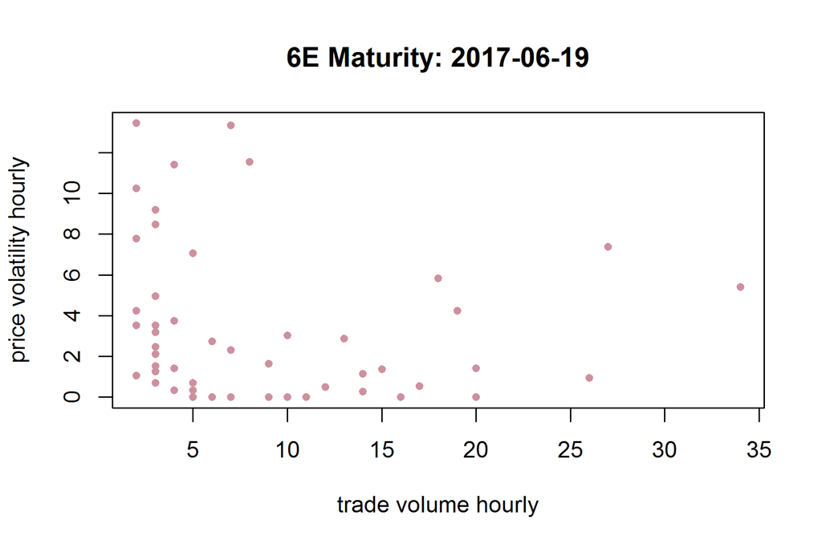

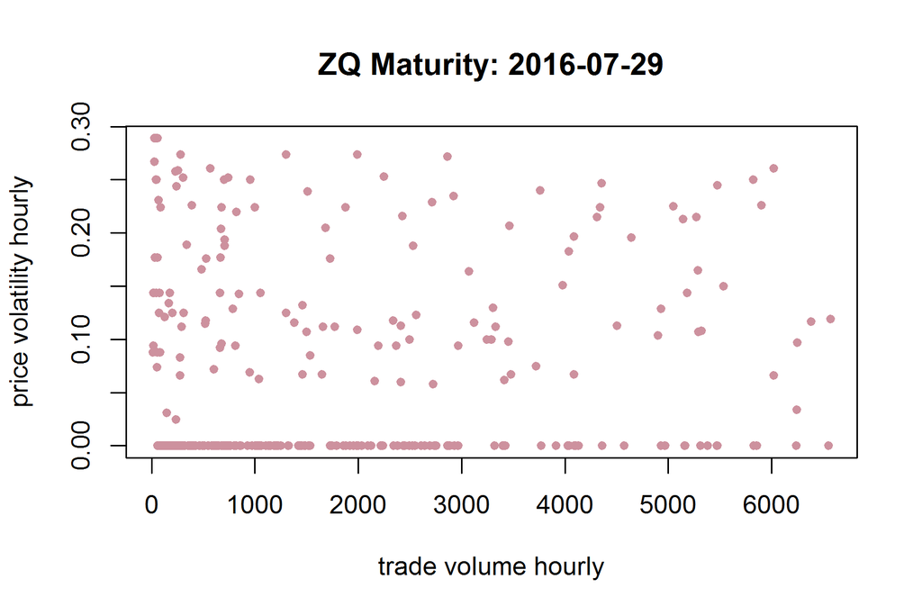

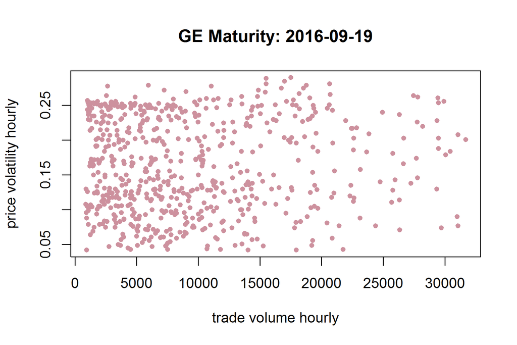

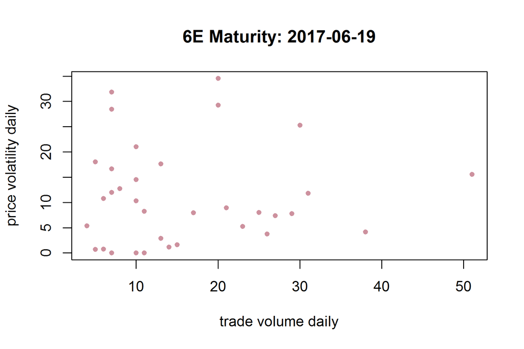

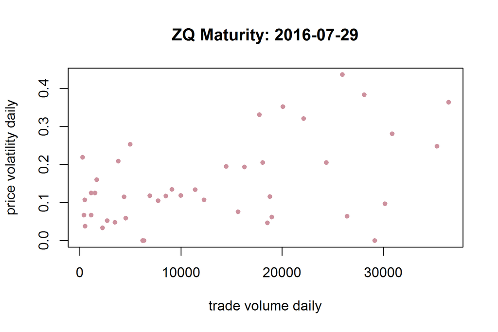

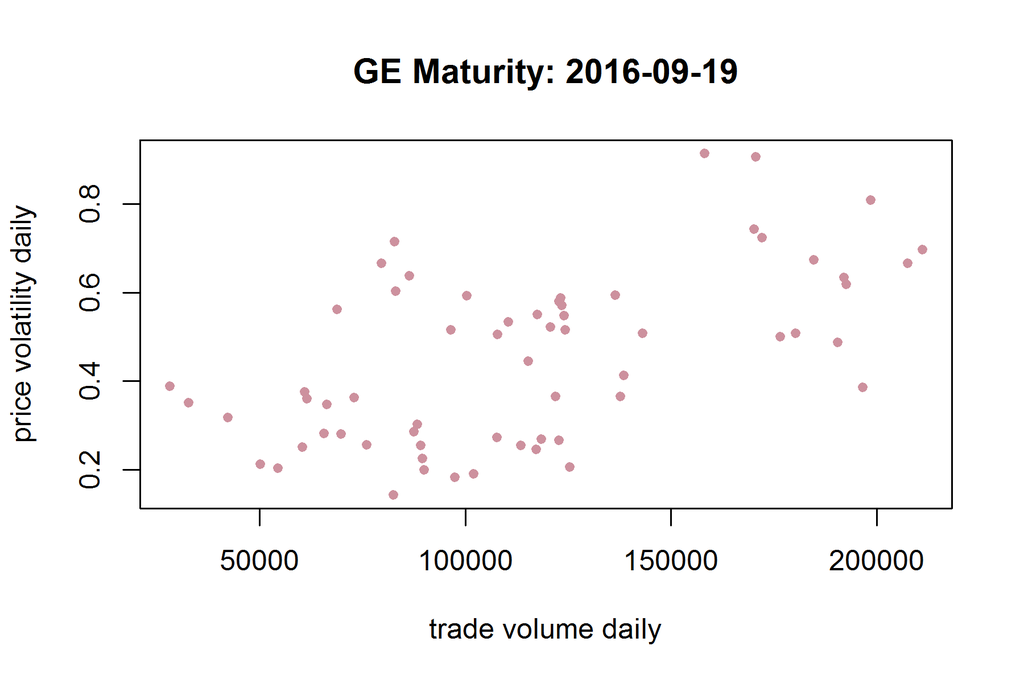

## Deviating Products Cont'd

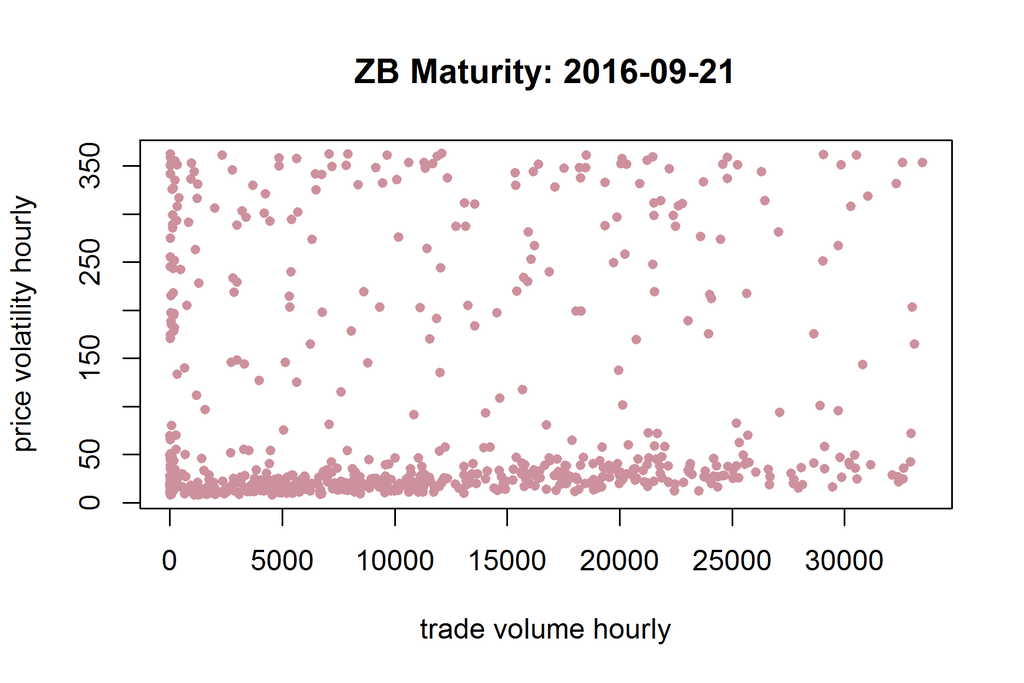

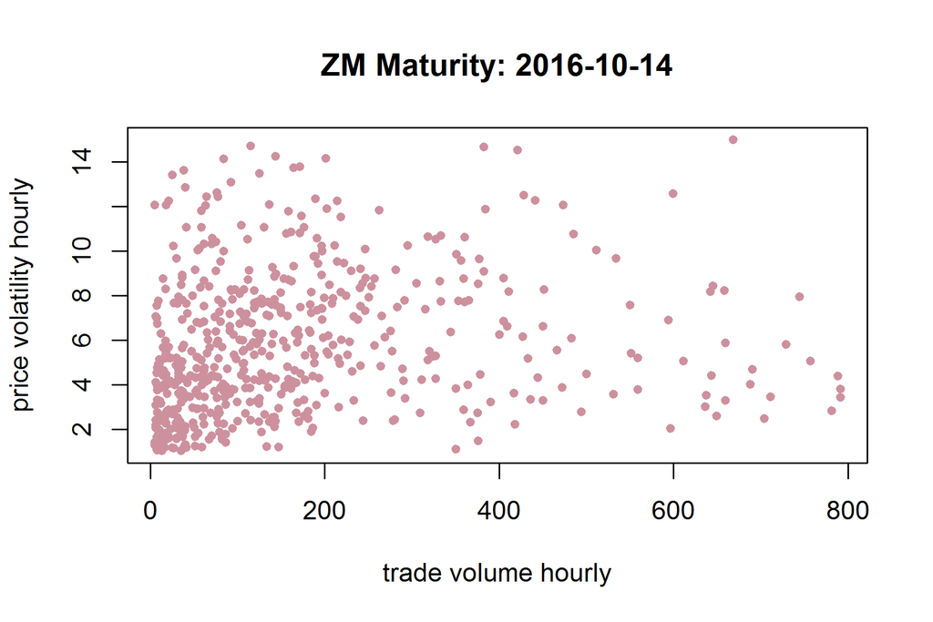

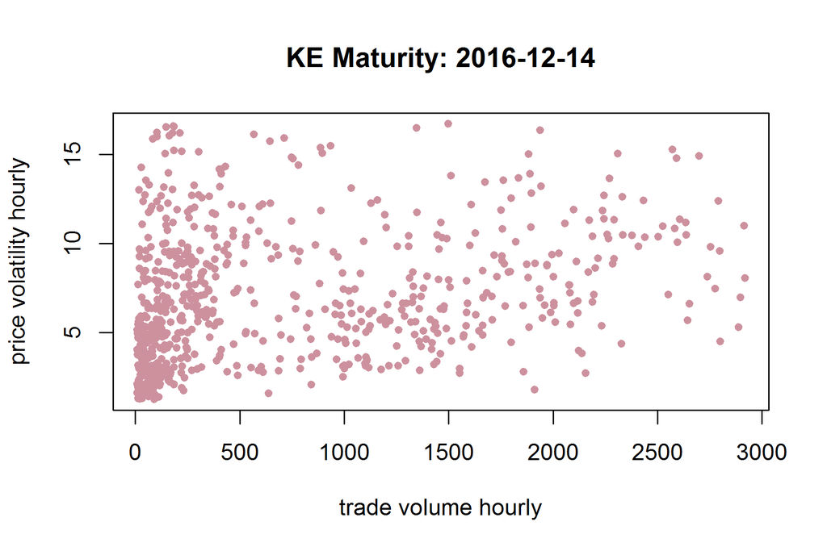

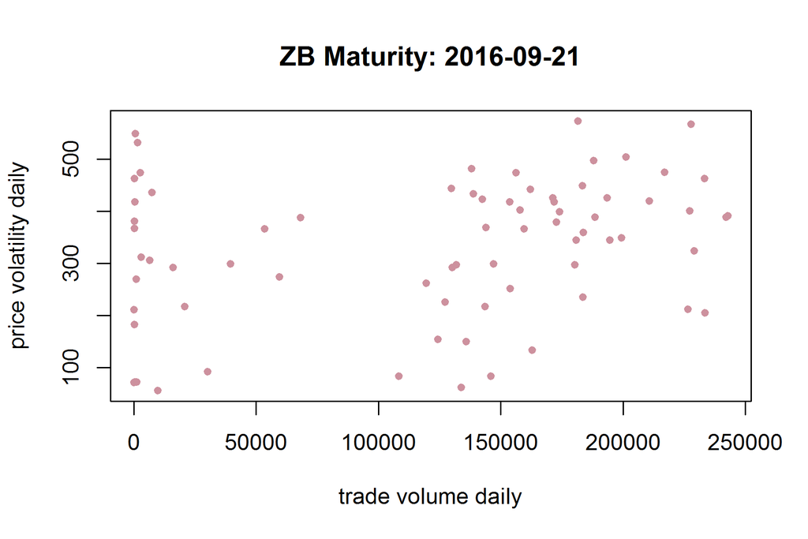

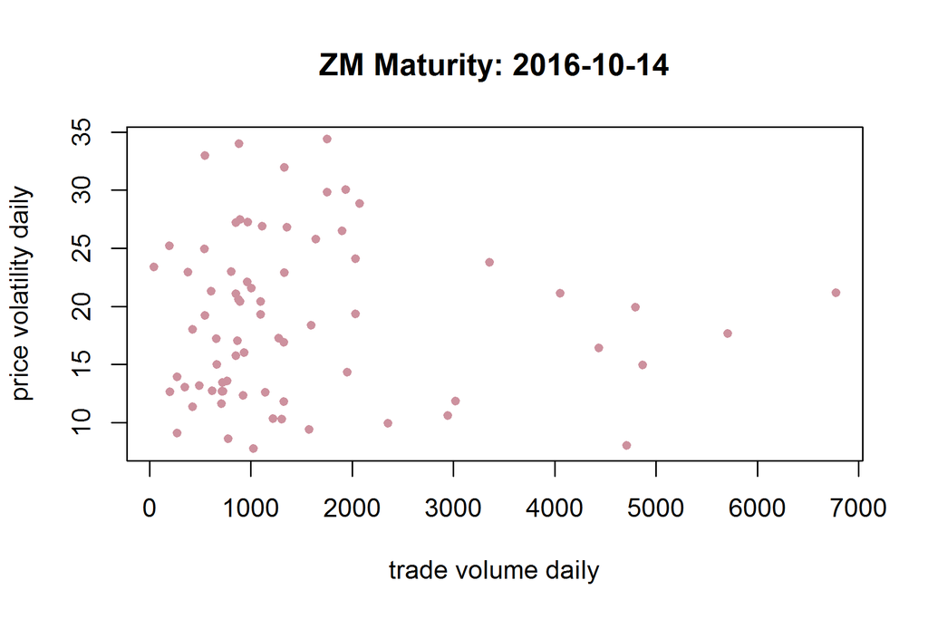

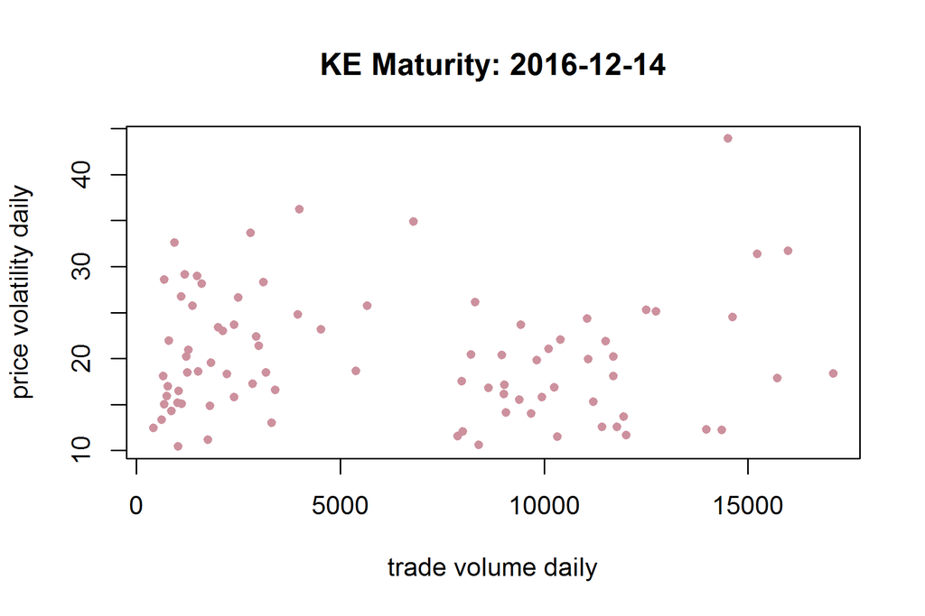

## What we Conclude

- Apache Spark is an efficient way to process massive datasets.
- Using a penalized regression spline is an effective way of predicting trade volume, granted products are similar and we have large set of data to fit models.
- The covariates most indicative of trade volume are time to maturity and instrument name
- Penalized regression splines are a useful tool for tasks such as building trading algorithms, improving traders' effectiveness, and controlling trading risk.

## Acknowledgements

Thanks to my graduate advisor, Professor Daniel Naiman.

Thanks also to the Johns Hopkins University Acheson J. Duncan Fund for their support of this research.

## Questions? Feedback welcome!